# STAT 6543 HW2 Osborn

STAT 6543  
HW 2  
Sheri Osborn

HW 2 Assignment

Chapter 03 (page 120): 2, 9, 10, 12

**2. Carefully explain the differences between the KNN classifier and KNN regression methods.**

KNN models are implementations based on the premise that things that share similar features tend to be similar. In classification, KNN classification puts a new datapoint with those datapoints that are closest in characteristic(s) and therefore is qualitative in nature. KNN approach for regressions is where we want to place a value rather than a classification. It approximates the association between independent variables and the continuous outcome by averaging the observations in the same neighborhood. It stores all available cases and predicts the numerical target based on a similarity measure (e.g., distance functions).

**9. This question involves the use of multiple linear regression on the Auto data set.**

1. Produce a scatterplot matrix which includes all of the variables in the data set.

```r
library(ISLR)
car = as.data.frame(Auto)
dim(car)
summary(car)
attach(car)
```

1. 392

2. 9

```
      mpg          cylinders      displacement     horsepower        weight
 Min.   : 9.00   Min.   :3.000   Min.   : 68.0   Min.   : 46.0   Min.   :1613
 1st Qu.:17.00   1st Qu.:4.000   1st Qu.:105.0   1st Qu.: 75.0   1st Qu.:2225
 Median :22.75   Median :4.000   Median :151.0   Median : 93.5   Median :2804
 Mean   :23.45   Mean   :5.472   Mean   :194.4   Mean   :104.5   Mean   :2978
 3rd Qu.:29.00   3rd Qu.:8.000   3rd Qu.:275.8   3rd Qu.:126.0   3rd Qu.:3615
 Max.   :46.60   Max.   :8.000   Max.   :455.0   Max.   :230.0   Max.   :5140

  acceleration        year           origin                      name
 Min.   : 8.00   Min.   :70.00   Min.   :1.000   amc matador       :  5
 1st Qu.:13.78   1st Qu.:73.00   1st Qu.:1.000   ford pinto        :  5
 Median :15.50   Median :76.00   Median :1.000   toyota corolla    :  5
 Mean   :15.54   Mean   :75.98   Mean   :1.577   amc gremlin       :  4
 3rd Qu.:17.02   3rd Qu.:79.00   3rd Qu.:2.000   amc hornet        :  4
 Max.   :24.80   Max.   :82.00   Max.   :3.000   chevrolet chevette:  4
                                                 (Other)           :365
```

```r
car = na.omit(car)
```

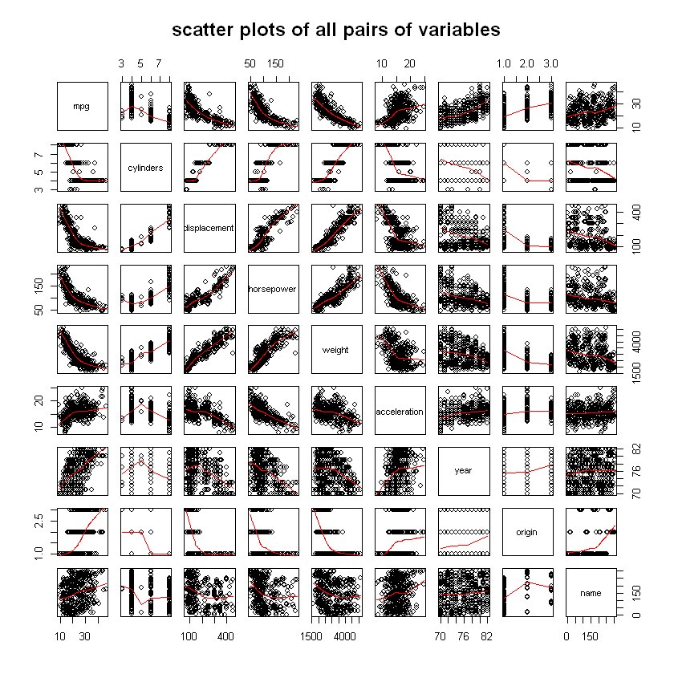

```r
#  9.(a). Produce a scatterplot matrix which includes all of the variables in the data set.
#
#

pairs(car,panel=panel.smooth,main="scatter plots of all pairs of variables")
```

```r
#  9.(b). Compute the matrix of correlations between the variables using the function cor().
#
#

library(dplyr)
cor(select(car, mpg, weight, displacement, cylinders, horsepower, acceleration, year, origin ))
```

|  | mpg | weight | displacement | cylinders | horsepower | acceleration | year | origin |
| --- | --- | --- | --- | --- | --- | --- | --- | --- |
| mpg | 1.0000000 | -0.8322442 | -0.8051269 | -0.7776175 | -0.7784268 | 0.4233285 | 0.5805410 | 0.5652088 |
| weight | -0.8322442 | 1.0000000 | 0.9329944 | 0.8975273 | 0.8645377 | -0.4168392 | -0.3091199 | -0.5850054 |
| displacement | -0.8051269 | 0.9329944 | 1.0000000 | 0.9508233 | 0.8972570 | -0.5438005 | -0.3698552 | -0.6145351 |
| cylinders | -0.7776175 | 0.8975273 | 0.9508233 | 1.0000000 | 0.8429834 | -0.5046834 | -0.3456474 | -0.5689316 |
| horsepower | -0.7784268 | 0.8645377 | 0.8972570 | 0.8429834 | 1.0000000 | -0.6891955 | -0.4163615 | -0.4551715 |
| acceleration | 0.4233285 | -0.4168392 | -0.5438005 | -0.5046834 | -0.6891955 | 1.0000000 | 0.2903161 | 0.2127458 |
| year | 0.5805410 | -0.3091199 | -0.3698552 | -0.3456474 | -0.4163615 | 0.2903161 | 1.0000000 | 0.1815277 |
| origin | 0.5652088 | -0.5850054 | -0.6145351 | -0.5689316 | -0.4551715 | 0.2127458 | 0.1815277 | 1.0000000 |

```r
#  9. (c). Use the lm() function to perform a multiple linear regression with mpg as the response and
#  all other variables except name as the predictors.
#
#
lmcar = lm(mpg ~ weight + displacement + cylinders + horsepower + acceleration + year + origin, data = car)
summary(lmcar)
```

```
Call:
lm(formula = mpg ~ weight + displacement + cylinders + horsepower +
    acceleration + year + origin, data = car)

Residuals:
    Min      1Q  Median      3Q     Max
-9.5903 -2.1565 -0.1169  1.8690 13.0604

Coefficients:
               Estimate Std. Error t value Pr(>|t|)
(Intercept)  -17.218435   4.644294  -3.707  0.00024 ***
weight        -0.006474   0.000652  -9.929  < 2e-16 ***
displacement   0.019896   0.007515   2.647  0.00844 **
cylinders     -0.493376   0.323282  -1.526  0.12780
horsepower    -0.016951   0.013787  -1.230  0.21963
acceleration   0.080576   0.098845   0.815  0.41548
year           0.750773   0.050973  14.729  < 2e-16 ***
origin         1.426141   0.278136   5.127 4.67e-07 ***
---
Signif. codes:  0 '***' 0.001 '**' 0.01 '*' 0.05 '.' 0.1 ' ' 1

Residual standard error: 3.328 on 384 degrees of freedom
Multiple R-squared:  0.8215,	Adjusted R-squared:  0.8182
F-statistic: 252.4 on 7 and 384 DF,  p-value: < 2.2e-16
```

*i. Is there a relationship between the predictors and the response?* Yes, we see a very low p-value for the F-statistic so we can reject H0 that Bi = 0.

*ii. Which predictors appear to have a statistically significant relationship to the response?* Weight, displacement, year and origin have a significant relationship to mpg as noted by the low p-values for each variable

*iii. What does the coefficient for the year variable suggest?* In this dataset, I would treat the year should be treated as a factor. Its qualitative, not quantitive. That said, its regression coefficient of 0.7507727, suggests that for every one year, mpg increases by the coefficient. In other words, cars become more fuel efficient every year by almost 1 mpg / year.

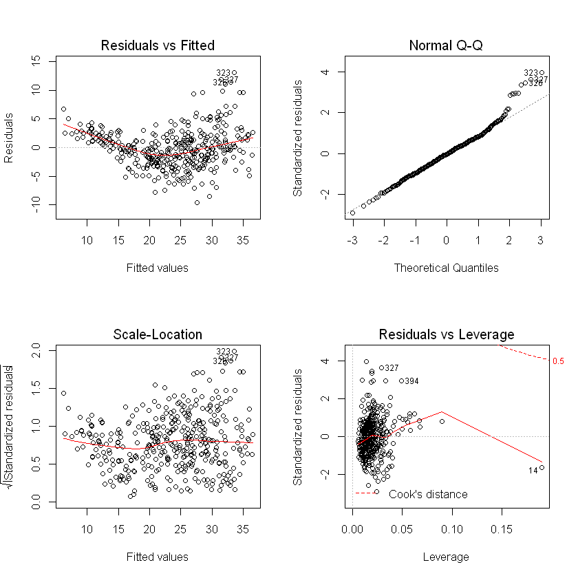

```r
# 9. (d) Use the plot() function to produce diagnostic plots of the linear regression fit.
#
#
par(mfrow = c(2, 2))
plot(lmcar)
```

Comment on any problems you see with the fit. Do the residual plots suggest any unusually large outliers? The Residual plot and the Standardized Residual plot both show a so-so linear fit though not a great one. At 30 and beyond a right-tailed skewness can be seen. The QQ plot confirms the fat right-tailed skewness beyond the 2nd positive quartile.

Does the leverage plot identify any observations with unusually high leverage? The leverage plot identifies observation 14 as potentially having significant leverage through it isn't beyond the Cook's distance line.

```r
#  9.(e) Use the * and : symbols to fit linear regression models with interaction effects.
#   Do any interactions appear to be statistically significant?
#
#
lm.mult.car = lm(mpg ~ (cylinders + displacement + horsepower)^2, data = car)
summary(lm.mult.car)
```

```
Call:
lm(formula = mpg ~ (cylinders + displacement + horsepower)^2,
    data = car)

Residuals:
     Min       1Q   Median       3Q      Max
-11.1907  -2.1959  -0.4285   1.9799  18.2020

Coefficients:
                          Estimate Std. Error t value Pr(>|t|)
(Intercept)             55.6718928  4.8692360  11.433  < 2e-16 ***
cylinders               -0.3603737  1.4593424  -0.247 0.805084
displacement            -0.1156195  0.0263010  -4.396 1.43e-05 ***
horsepower              -0.2509992  0.0550410  -4.560 6.88e-06 ***
cylinders:displacement   0.0025919  0.0031956   0.811 0.417818
cylinders:horsepower     0.0048743  0.0126823   0.384 0.700937
displacement:horsepower  0.0005099  0.0001420   3.590 0.000374 ***
---
Signif. codes:  0 '***' 0.001 '**' 0.01 '*' 0.05 '.' 0.1 ' ' 1

Residual standard error: 3.935 on 385 degrees of freedom
Multiple R-squared:  0.7498,	Adjusted R-squared:  0.7459
F-statistic: 192.3 on 6 and 385 DF,  p-value: < 2.2e-16
```

*Commentary:* As independent variables cylynders doesn't have a linear relationship with mpg. Displacement and horsepower individually show a statistical significance of influence on MPG. The interaction terms cylinders:displacement and cylinders:horsepower are not statistcally significant. displacement:horsepower interaction variable show a statistical significance in influence on MPG.

```r
#  9. (f) Try a few different transformations of the variables, such as log(X), √ X, X2.
#  Comment on your findings
#
#


lm.car.logwt = lm(mpg ~ log(weight) + displacement + cylinders + horsepower + acceleration + year + origin, data = car)
summary(lm.car.logwt)
```

```
Call:
lm(formula = mpg ~ log(weight) + displacement + cylinders + horsepower +
    acceleration + year + origin, data = car)

Residuals:
   Min     1Q Median     3Q    Max
-9.382 -1.973 -0.016  1.681 12.803

Coefficients:
               Estimate Std. Error t value Pr(>|t|)
(Intercept)  133.138912  11.531157  11.546  < 2e-16 ***
log(weight)  -21.858785   1.651400 -13.237  < 2e-16 ***
displacement   0.020977   0.006825   3.074 0.002265 **
cylinders     -0.432749   0.299977  -1.443 0.149946
horsepower    -0.010072   0.012546  -0.803 0.422593
acceleration   0.135179   0.089798   1.505 0.133051
year           0.788784   0.047596  16.573  < 2e-16 ***
origin         1.011407   0.262262   3.856 0.000135 ***
---
Signif. codes:  0 '***' 0.001 '**' 0.01 '*' 0.05 '.' 0.1 ' ' 1

Residual standard error: 3.091 on 384 degrees of freedom
Multiple R-squared:  0.8459,	Adjusted R-squared:  0.8431
F-statistic: 301.2 on 7 and 384 DF,  p-value: < 2.2e-16
```

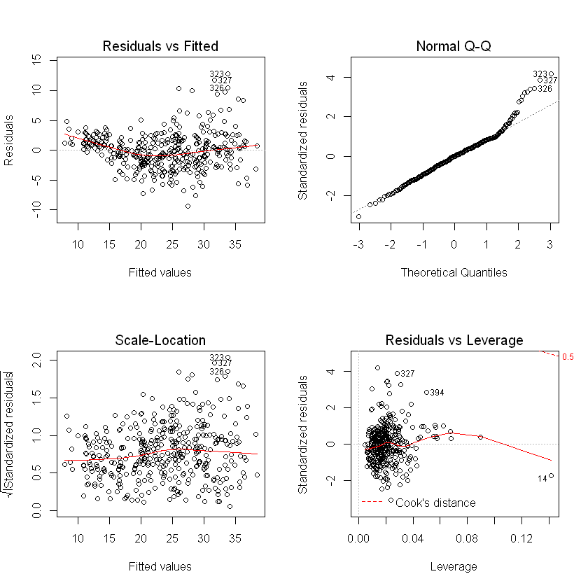

```r
par(mfrow = c(2, 2))
plot(lm.car.logwt)
```